# Assigment 2

Roberto Altran

15/10/2021

### 1. Analysis of Fortune 500 Companies

1. Open the dataset MKTVALUE.csv on stream. This data, kindly provided by former Massey MBA student Alan Chan, is part of a set of data for Fortune 500 companies. We will consider the relationship between the variables MktValue (market value of the company) and Profits (most recent annual profit). The dataset also contains information on Assets (book value of assets) all in millions of US dollars.

Read in the data and show the head and tail of the variables.

```r
MKTVALUE = read.csv("/Users/robertoaltran/Documents/regression modeling/MKTVALUE.csv", header=TRUE)
attach(MKTVALUE )
```

2. Fit a fifth-degree polynomial for MktValue in terms of Profits. Comment whether the p-values of the coefficients suggests simplifying the model.

```r
  lm1 = lm(MktValue ~ poly(Profits, 5, raw=TRUE))
summary(lm1)
```

```
##
## Call:
## lm(formula = MktValue ~ poly(Profits, 5, raw = TRUE))
##
## Residuals:
##    Min     1Q Median     3Q    Max
## -55536  -4921  -2645   1489 107789
##
## Coefficients:
##                                 Estimate Std. Error t value Pr(>|t|)
## (Intercept)                    6.526e+03  1.136e+03   5.744 1.89e-08 ***
## poly(Profits, 5, raw = TRUE)1  5.445e+00  2.627e+00   2.073  0.03886 *
## poly(Profits, 5, raw = TRUE)2  8.707e-03  2.850e-03   3.055  0.00241 **
## poly(Profits, 5, raw = TRUE)3  4.325e-07  1.460e-06   0.296  0.76723
## poly(Profits, 5, raw = TRUE)4 -5.648e-10  2.655e-10  -2.127  0.03404 *
## poly(Profits, 5, raw = TRUE)5  5.007e-14  1.544e-14   3.244  0.00128 **
## ---
## Signif. codes:  0 '***' 0.001 '**' 0.01 '*' 0.05 '.' 0.1 ' ' 1
##
## Residual standard error: 15150 on 382 degrees of freedom
## Multiple R-squared:  0.7472, Adjusted R-squared:  0.7439
## F-statistic: 225.8 on 5 and 382 DF,  p-value: < 2.2e-16
```

Comment: In general the coefficients are significants. But the number 3 is not nthe p-value is >0.05. So, we can make the model better simplifying it.

3. Using the FittedLinePlot function or otherwise, plot the 5th degree polynomial model for MktValue in terms of Profits, with 95% prediction bounds for the MktValue. Based on the graph, comment on reasons why the model needs to be improved.

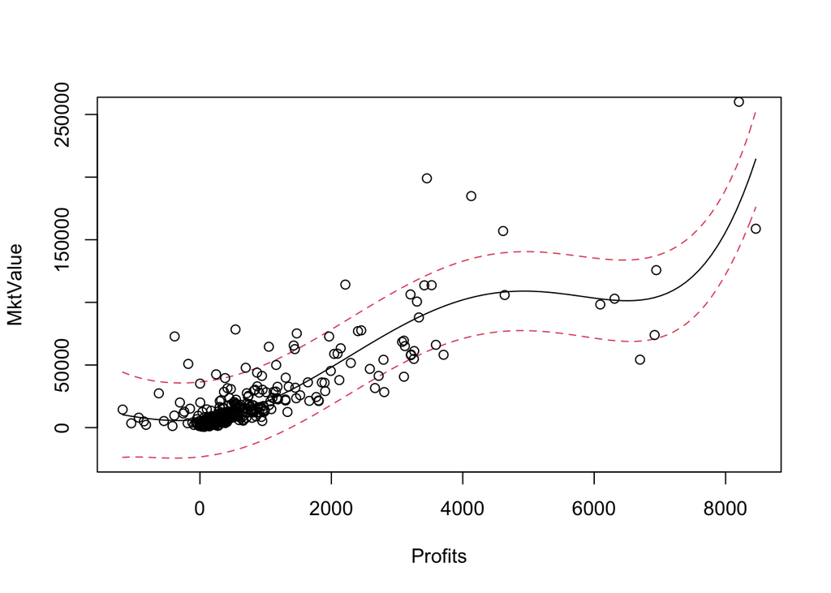

```r
FittedLinePlot = function(xydata, polyn=5,showpoints=TRUE){
x= xydata[,1] ;  y= xydata[,2]
varname=names(xydata)
model = lm(y~ poly(x,polyn))
pred.x = data.frame( x =min(x) + (0:100)*(max(x)-min(x) )/100)
pred.y =predict(model, newdata = pred.x, interval = "prediction")
matplot(pred.x, pred.y ,  lty=c(1,2,2), col=c(1,2,2), type="l",xlab =varname[1],ylab=varname[2])
if(showpoints) matpoints(x,y, pch=1)
datapred = predict(model, newdata = data.frame(x), interval = "prediction")
cbind(xydata,datapred)
 }


m.flp = FittedLinePlot(data.frame(Profits, MktValue), polyn=5)
```

Comment:  
The model is not capturing the data very well.

(d)(i) Plot the histogram and normal Q-Q plot of the residuals from the 5th degree polynomial in part (b). Are they normal? If not, describe their distribution.

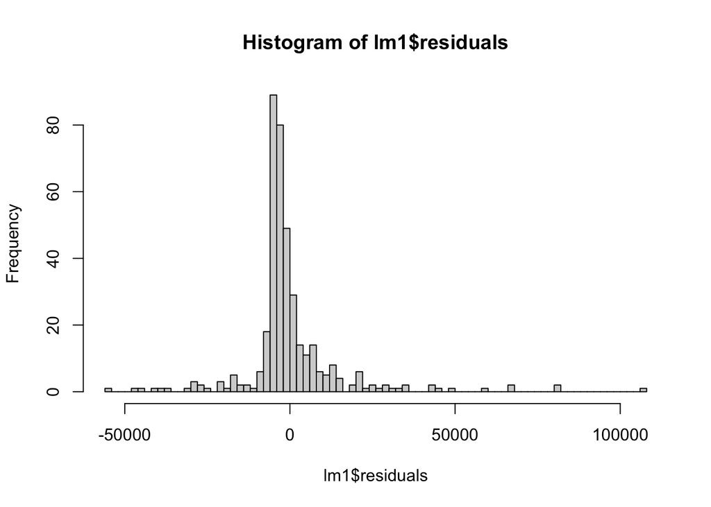

```r
hist(lm1$residuals, breaks=c(100))
```

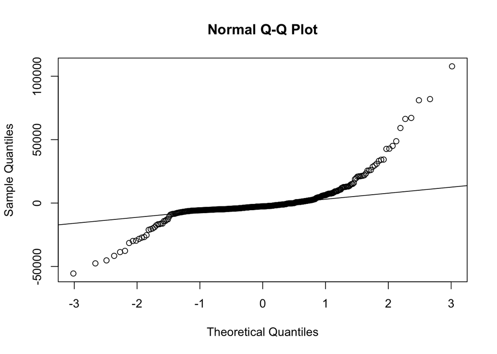

```r
qqnorm(lm1$residuals)
qqline(lm1$residuals)
```

Comment:  
They are not normal. I would consider a right-skewed (or positively skewed).

(d)(ii) Explain why would be useless to try to fix normality by plotting log(MktValue) against log(Profits) ? (Hint: consider the data.)

Comment:  
Because it can not help with the curve. And also some datas will be not captured.

5. Suppose we consider a piecewise model which is initially flat and then rises proportionately to Profits. We consider a modified predictor
   $$Profit_k = k+ (abs( Profit-k)+ Profit-k)/2 ~.$$
   The choice of k will be based on the data, with the need to minimize the residual sum of squares. For example Profit1 will equal 1 whenever the profit is $\le 1$ million), and will equal Profit whenever Profits exceed 1 million. We can do this using the formula:
   $$Profit1 = 1+ (abs(Profits-1) +Profits-1)/2$$

This formula can be modified for other values of k:
$$PROF100 = 100+(abs(Profits-100) +Profits-100)/2$$
$$PROF200 = 200+(abs(Profits-200) +Profits-200)/2$$

Regress (i) Y=MktValue against X=‘Profits’. (only show model summary output). Then  
similarly (ii) Y=MKTVALUE against X=‘Profit1’. Is this a better model?

Similarly (iii) regress Y vs Profit100

and again (iv) Y vs Profit200.

Which cutpoint gives the best model? State your criterion for ‘best model’.

```r
Profit1 =  1+ (abs(Profits-1) +Profits-1)/2
lm2 = lm( MktValue ~  Profits)
lm3 = lm( MktValue ~  Profit1)
summary(lm2)
```

```
##
## Call:
## lm(formula = MktValue ~ Profits)
##
## Residuals:
##    Min     1Q Median     3Q    Max
## -85729  -5579  -3443    635 124673
##
## Coefficients:
##              Estimate Std. Error t value Pr(>|t|)
## (Intercept) 4527.1096   985.7564   4.593 5.94e-06 ***
## Profits       20.2216     0.6864  29.459  < 2e-16 ***
## ---
## Signif. codes:  0 '***' 0.001 '**' 0.01 '*' 0.05 '.' 0.1 ' ' 1
##
## Residual standard error: 16640 on 386 degrees of freedom
## Multiple R-squared:  0.6922, Adjusted R-squared:  0.6914
## F-statistic: 867.9 on 1 and 386 DF,  p-value: < 2.2e-16
```

```r
summary(lm3)
```

```
##
## Call:
## lm(formula = MktValue ~ Profit1)
##
## Residuals:
##    Min     1Q Median     3Q    Max
## -88782  -4894  -2714    902 123545
##
## Coefficients:
##              Estimate Std. Error t value Pr(>|t|)
## (Intercept) 3605.7826   971.6195   3.711 0.000237 ***
## Profit1       20.8151     0.6792  30.645  < 2e-16 ***
## ---
## Signif. codes:  0 '***' 0.001 '**' 0.01 '*' 0.05 '.' 0.1 ' ' 1
##
## Residual standard error: 16180 on 386 degrees of freedom
## Multiple R-squared:  0.7087, Adjusted R-squared:  0.7079
## F-statistic: 939.1 on 1 and 386 DF,  p-value: < 2.2e-16
```

```r
Profit2 =  100+ (abs(Profits-100) +Profits-100)/2
Profit3 =  200+ (abs(Profits-200) +Profits-200)/2
lm4 = lm( MktValue ~  Profit2)
lm5 = lm( MktValue ~  Profit3)
summary(lm4)
```

```
##
## Call:
## lm(formula = MktValue ~ Profit2)
##
## Residuals:
##    Min     1Q Median     3Q    Max
## -89454  -4598  -2678    823 123376
##
## Coefficients:
##              Estimate Std. Error t value Pr(>|t|)
## (Intercept) 3239.7091   973.6821   3.327 0.000961 ***
## Profit2       20.9700     0.6804  30.818  < 2e-16 ***
## ---
## Signif. codes:  0 '***' 0.001 '**' 0.01 '*' 0.05 '.' 0.1 ' ' 1
##
## Residual standard error: 16120 on 386 degrees of freedom
## Multiple R-squared:  0.711,  Adjusted R-squared:  0.7103
## F-statistic: 949.7 on 1 and 386 DF,  p-value: < 2.2e-16
```

```r
summary(lm5)
```

```
##
## Call:
## lm(formula = MktValue ~ Profit3)
##
## Residuals:
##    Min     1Q Median     3Q    Max
## -90333  -4925  -2668   1005 123284
##
## Coefficients:
##              Estimate Std. Error t value Pr(>|t|)
## (Intercept) 2492.5095   987.4766   2.524    0.012 *
## Profit3       21.2128     0.6887  30.801   <2e-16 ***
## ---
## Signif. codes:  0 '***' 0.001 '**' 0.01 '*' 0.05 '.' 0.1 ' ' 1
##
## Residual standard error: 16120 on 386 degrees of freedom
## Multiple R-squared:  0.7108, Adjusted R-squared:   0.71
## F-statistic: 948.7 on 1 and 386 DF,  p-value: < 2.2e-16
```

Comment: All them perform good. But the Profit2 is the best model considering the p-value, Residual standard error, and R^2 .

6. Perform a nonlinear regression of Mktvalue vs the model expression *beta0 + beta1* * *( k + (abs(Profits-k)+Profits-k)/2 )*

```r
Mkt.nls = nls(MktValue ~ beta0 + beta1 *  I(k + (abs(Profits - k) + Profits - k)/2), start = list(k=100,  beta0 = 3239.70,  beta1= 20.97 ), data = MKTVALUE, nls.control(warnOnly = TRUE, minFactor = 1/2048))
summary (Mkt.nls)
```

```
##
## Formula: MktValue ~ beta0 + beta1 * I(k + (abs(Profits - k) + Profits -
##     k)/2)
##
## Parameters:
##        Estimate Std. Error t value Pr(>|t|)
## k      145.4352    93.8616   1.549   0.1221
## beta0 2955.8495  1193.1854   2.477   0.0137 *
## beta1   21.0691     0.7202  29.256   <2e-16 ***
## ---
## Signif. codes:  0 '***' 0.001 '**' 0.01 '*' 0.05 '.' 0.1 ' ' 1
##
## Residual standard error: 16130 on 385 degrees of freedom
##
## Number of iterations to convergence: 2
## Achieved convergence tolerance: 9.542e-08
```

Replace the ***** with initial parameter estimates from the best model in part (e).

1. Show a summary of the model results.
2. Calculate (by hand) a confidence interval for k. Does this include your chosen number from part (e)? Do we know k fairly accurately?
3. In terms of residual standard error, is this a better model than the one with your chosen value of k?

```r
est = summary(Mkt.nls)$coefficients[1]
se = summary(Mkt.nls)$coefficients[4]
lower = est + qt(0.025, df = 15 - 3) * se
upper = est + qt(0.975, df = 15 - 3) * se
cbind(est, se, lower, upper)
```

```
##           est       se     lower   upper
## [1,] 145.4352 93.86155 -59.07153 349.942
```

Comments: No. According the residual standart error, the best model is Lm4, the one which K was chosen.

7. Examine the plot() output for your chosen model in (e). Explain why it might be reasonable to think that a weighted regression with weights Wt $\propto$ 1/Predicted values might do better.

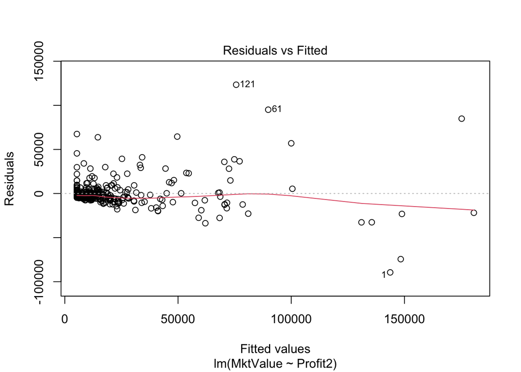

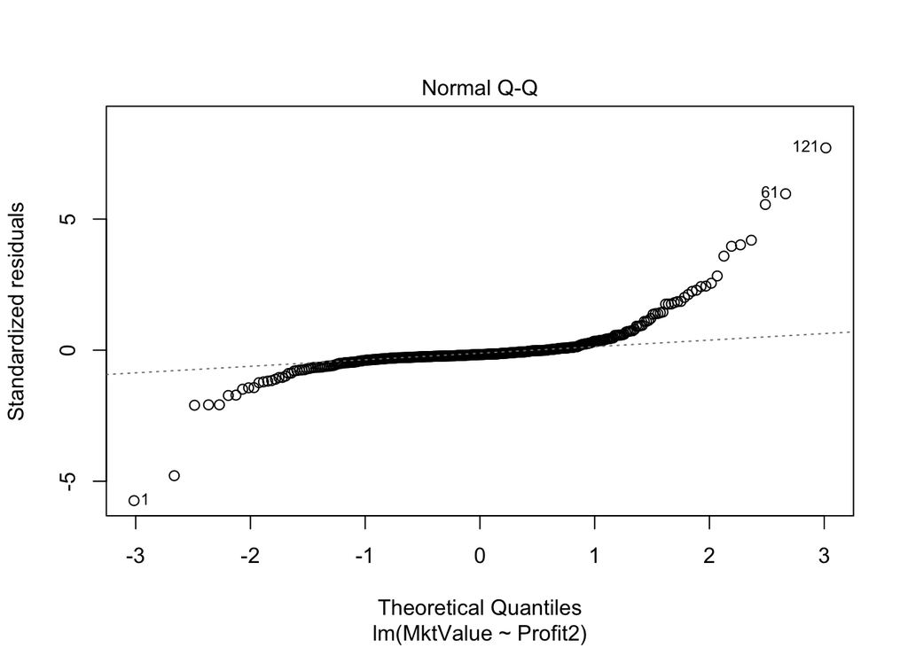

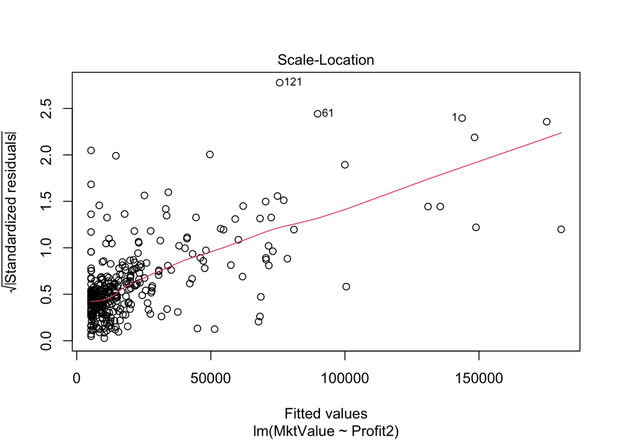

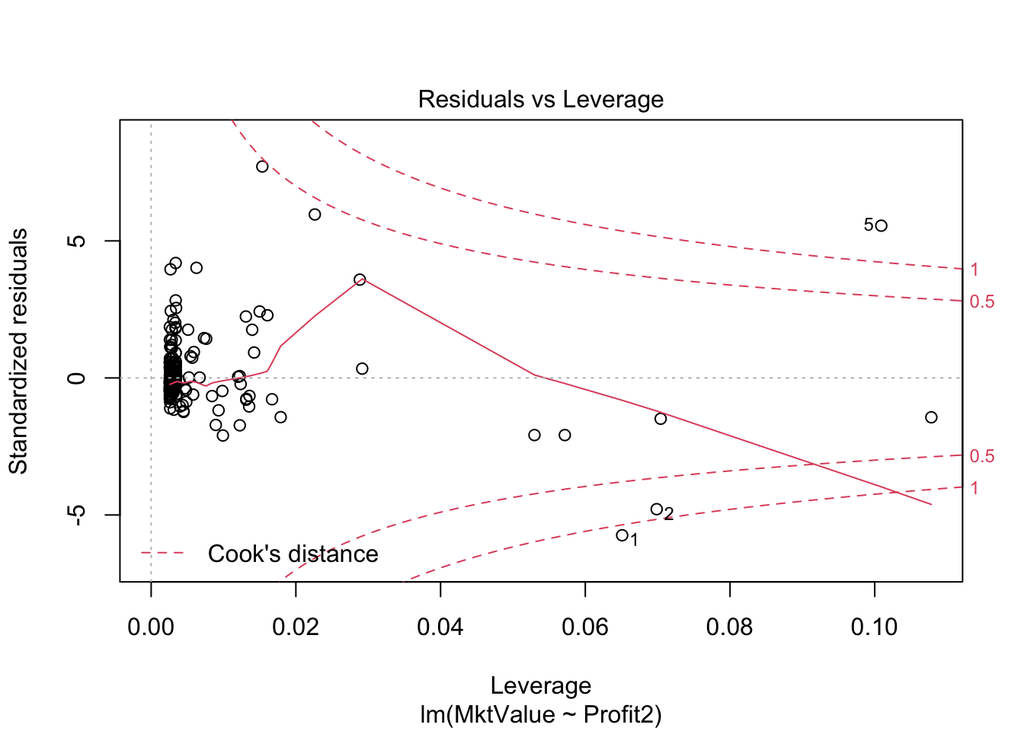

```r
 plot(lm4)
```

It has heteroscedasticity, which using the weighted regression could help descreasing the heteroscedasticity.

8. Fit a weighted regression of your chosen model in (e) but with Wt= 1/Predicted values.
9. Show summary.
2. Calculate the Weighted residuals (i.e. Pearson residuals) and plot them against Profits.
3. Identify the Company with the biggest Weighted residual (Hint: row (1:n)[Wtres==max(Wtres)] )
4. Aside from that Company has the heteroscedasticity been improved?

```r
lmw = lm(MktValue ~ Profit2, weights= 1/predict(lm4))
summary(lmw)
n= length(Wtres)
(1:n)[Wtres==max(Wtres)]
Company[(1:n)[Wtres==max(Wtres)]]
plot(Wtres ~ Profits)
```

[output not shown]

Comments: Yes it has.

### 2. Analysis of World Values Survey

Open the dataset WVS2005NZAssnt2.csv available on Stream. This is responses from the 2005 World Values Survey (some columns deleted and columns renamed). Variables in the dataset are:

| Variable | Description |  |
| --- | --- | --- |
| V3ID | ID number | Coding method |
| V4FamilyImp | Family is important | 1= Very important, 2= Rather Important, 3= Not Very Important, 4= Not At All Important |
| V5FrndsImp | Friends are important | same as for V4familyImp |
| V6LesrImp | Leisure is important | same as for V4familyImp |
| V7PoltcImp | Politics is important | same as for V4familyImp |
| V8WorkImp | Work is important | same as for V4familyImp |
| V9RelgnImp | Religion is important | same as for V4familyImp |
| V10FeelHappy | Feel Happy | 1= Very Happy, 2=Quite Happy, 3= Not Very Happy, 4= Not At All Happy |
| V11StateofHlth | State of health | 1= Very good health, 2= Good health, 3= Fair Health, 4= Poor health |
| V22SatisfLife | Satisfaction with my life | 1= Dissatisfied, 2,3,4,5,6,7,8,9, 10= Satisfied |
| V235Sex | Sex | 1= male, 2= female |
| V237Age | Age | years 18,19,…,89,90. |
| V238HighEducLev | Highest Eduction Level | 1=No formal education, 2= Primary/Kura/Intermediate, 3= Up to 3 years Secondary, 4= 4 or more years Secondary, 5= Polytech/Wananga/some Uni/etc. 6=Degree |
| V253Income | Income Decile | 1= Lowest Decile, 2,3,3,4,5,6,7,8,9, 10= Highest Decile |
| VeryHappy | Feel Very Happy | 1= True, 0=False |
| V23MostTrusted | Most people can be trusted | 1=True, 0=False |
| MaritalStatus | Marital Status | 1=Single/Never married nor partnered, 2= Married/Partnered, 3=Separated/Widowed/Divorced |

Use the following code to read in the data and to remove all rows that have any missing values (NA). Note capital “V”s.

```r
WVS = read.csv("/Users/robertoaltran/Documents/regression modeling/WVS2005NZAssnt2.csv",  header=TRUE)
head(WVS) ; attach(WVS)
```

```
##   V3ID V4FamilyImp V5FrndsImp V6LesrImp V7PoltcImp V8WorkImp V9RelgnImp
## 1 1002           1          1         2          3         2          3
## 2 1003           1          1         1          3         3          2
## 3 1004           1          2         3          3         2          1
## 4 1006           1          1         1          1         1          1
## 5 1008           1          1         1          3         1          3
## 6 1009           1          1         1          2         1          4
##   V10FeelHappy V11StateofHlth V22SatisfLife V235Sex V237Age V238HighEducLev
## 1            1              1             9       2      68               8
## 2            1              4            10      NA      NA              NA
## 3            1              2             9       2      31               7
## 4            1              3            10       2      60               7
## 5            2              2             6       1      49               8
## 6            2              1             8       2      46               7
##   V253Income VeryHappy V23MostTrusted MaritalStatus
## 1          1         1              1             1
## 2         NA         1              0             2
## 3          8         1              0             2
## 4          1         1              0             2
## 5          6         0              0             2
## 6          1         0              0             3
```

```r
subtotal =V22SatisfLife +V237Age+V11StateofHlth  #finding NAs
WVS1=WVS[!is.na(subtotal),]

attach(WVS1)
```

1. Consider the response variable V22SatisfLife (How satisfied are you with your life). This has levels 1 (Dissatisfied) through to 10 (Satisfied). Check this response variable for normality / skewness. Show graph(s). What do you conclude?

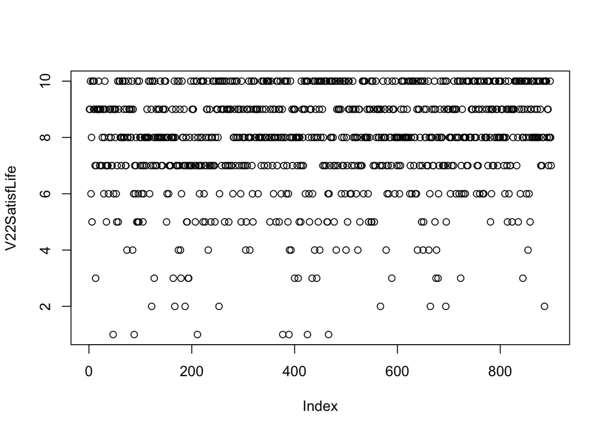

```r
plot(V22SatisfLife)
```

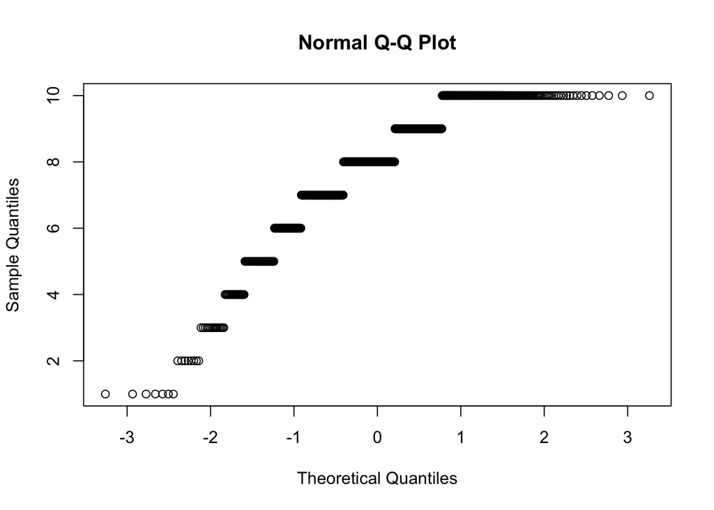

```r
qqnorm(V22SatisfLife)
```

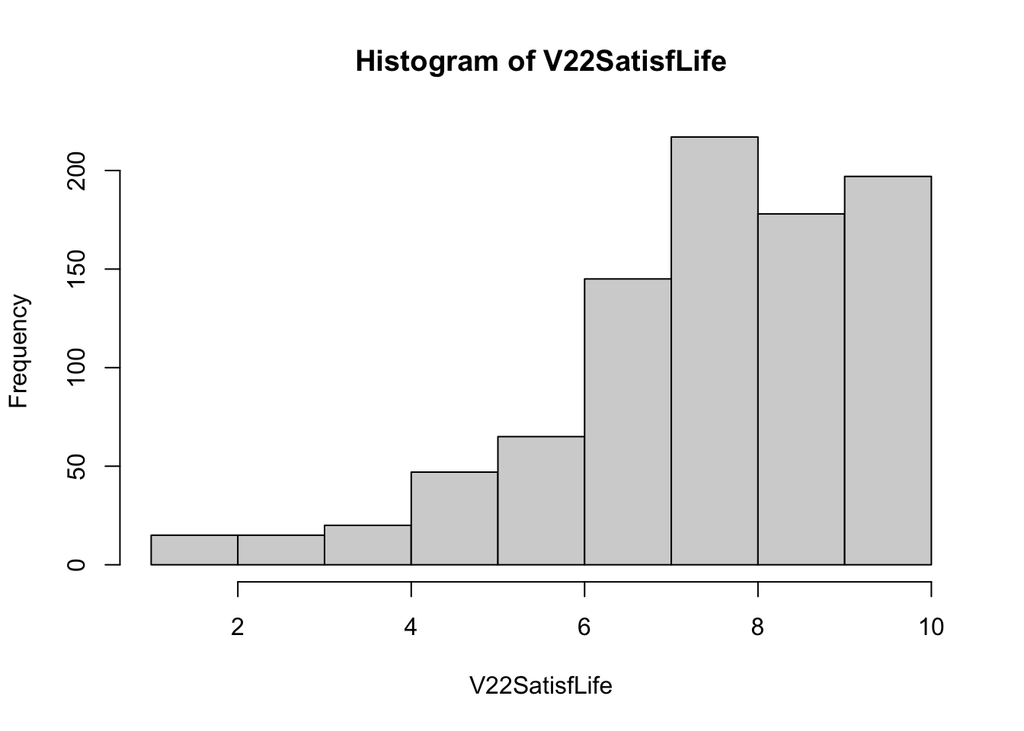

```r
hist(V22SatisfLife)
```

Comments: Is it not normall distributed, and left skewed.

2. Calculate a new variable Satisfact2 = the square of the Satisfaction variable.

Fit a linear model with response Satisfact2 and covariate V237Age (Age in years) and fixed factor V11StateofHlth (State of Health – subjective). Also include the interaction of these two.

```r
summary(V237Age)
```

```
##    Min. 1st Qu.  Median    Mean 3rd Qu.    Max.
##   18.00   36.00   49.00   49.18   61.00   89.00
```

```r
table(V11StateofHlth)
```

```
## V11StateofHlth
##   1   2   3   4
## 334 404 142  19
```

```r
Satisfact2 = V22SatisfLife**2
WVS.lm = lm( Satisfact2 ~  V237Age )
summary(WVS.lm)
```

```
##
## Call:
## lm(formula = Satisfact2 ~ V237Age)
##
## Residuals:
##     Min      1Q  Median      3Q     Max
## -69.908 -15.755   0.476  19.254  42.493
##
## Coefficients:
##             Estimate Std. Error t value Pr(>|t|)
## (Intercept) 52.31091    2.71485   19.27  < 2e-16 ***
## V237Age      0.27349    0.05239    5.22 2.22e-07 ***
## ---
## Signif. codes:  0 '***' 0.001 '**' 0.01 '*' 0.05 '.' 0.1 ' ' 1
##
## Residual standard error: 25.63 on 897 degrees of freedom
## Multiple R-squared:  0.02948,    Adjusted R-squared:  0.0284
## F-statistic: 27.25 on 1 and 897 DF,  p-value: 2.223e-07
```

```r
anova(WVS.lm)
```

```
## Analysis of Variance Table
##
## Response: Satisfact2
##            Df Sum Sq Mean Sq F value    Pr(>F)
## V237Age     1  17898 17898.2  27.249 2.223e-07 ***
## Residuals 897 589175   656.8
## ---
## Signif. codes:  0 '***' 0.001 '**' 0.01 '*' 0.05 '.' 0.1 ' ' 1
```

1. Show the summary and anova(). Are Age and State of health significantly related to life satisfaction**2. Is the interaction significant?

2. Plot the fitted values from the model against the predictor Age, with separate symbols for each level of State of Health. Summarise in words what this graph shows you about how life satisfaction varies with Age for each State of Health.

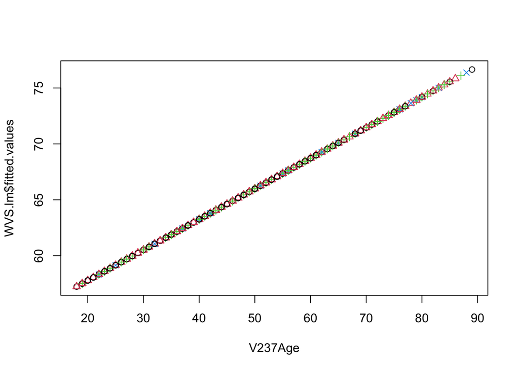

```r
plot(V237Age,   WVS.lm$fitted.values,  pch= V11StateofHlth, col= V11StateofHlth)
```

*Comment:* Apparently older people get happier they are.

4. Using the summary output, or otherwise, what is the formula for the predicted line in terms of Age when State of health is ‘good’ (V11StateofHlth=2)?

Comment: (Hint write in the form Satisfact2 = a + b *Age)

The reduced dataset WVS2 below has all missing values (NA) removed. Attach(WVS2) and re-calculate Satisfact2 = V22SatisfLife**2.

```r
total=apply(WVS,1,sum)   # finding NAs across all columns of WVS
WVS2=WVS[!is.na(total),]
attach(WVS2)
head(WVS2)
```

```
##   V3ID V4FamilyImp V5FrndsImp V6LesrImp V7PoltcImp V8WorkImp V9RelgnImp
## 1 1002           1          1         2          3         2          3
## 3 1004           1          2         3          3         2          1
## 4 1006           1          1         1          1         1          1
## 5 1008           1          1         1          3         1          3
## 6 1009           1          1         1          2         1          4
## 8 1012           1          2         2          2         1          2
##   V10FeelHappy V11StateofHlth V22SatisfLife V235Sex V237Age V238HighEducLev
## 1            1              1             9       2      68               8
## 3            1              2             9       2      31               7
## 4            1              3            10       2      60               7
## 5            2              2             6       1      49               8
## 6            2              1             8       2      46               7
## 8            1              1            10       1      32               6
##   V253Income VeryHappy V23MostTrusted MaritalStatus
## 1          1         1              1             1
## 3          8         1              0             2
## 4          1         1              0             2
## 5          6         0              0             2
## 6          1         0              0             3
## 8          4         1              0             2
```

```r
Satisfact2 = V22SatisfLife**2
```

3. Perform a backwards stepwise regression of Satisfact2 vs all of the variables from v4 Family Important through to v9 Religion Important, and factor(V11StateofHlth), v235 Sex, v237 Age, V238 Highest education level, V253 Income and factor(MaritalSTatus) (12 predictors). See coding hints below.

```r
lm.null= lm(Satisfact2 ~ 1)
lm.full = lm(Satisfact2~ V4FamilyImp    +V5FrndsImp+    V6LesrImp+  V7PoltcImp+ V8WorkImp+  V9RelgnImp+ factor(V11StateofHlth)+ V235Sex + V237Age + V238HighEducLev + V253Income+ factor(MaritalStatus))

lms = step( lm.full, scope=list(lower=lm.null, upper=lm.full), direction="backward")
```

```
## Start:  AIC=4334.93
## Satisfact2 ~ V4FamilyImp + V5FrndsImp + V6LesrImp + V7PoltcImp +
##     V8WorkImp + V9RelgnImp + factor(V11StateofHlth) + V235Sex +
##     V237Age + V238HighEducLev + V253Income + factor(MaritalStatus)
##
##                          Df Sum of Sq    RSS    AIC
## - V8WorkImp               1         4 339487 4332.9
## - V6LesrImp               1       153 339636 4333.2
## - V235Sex                 1       219 339702 4333.4
## - V4FamilyImp             1       285 339768 4333.5
## - V7PoltcImp              1       337 339819 4333.6
## - V238HighEducLev         1       548 340031 4334.1
## - V9RelgnImp              1       871 340354 4334.7
## <none>                                339483 4334.9
## - V5FrndsImp              1      1499 340982 4336.0
## - V253Income              1      2568 342051 4338.2
## - factor(MaritalStatus)   2      8354 347837 4347.8
## - V237Age                 1     13061 352544 4359.2
## - factor(V11StateofHlth)  3     47618 387101 4420.2
##
## Step:  AIC=4332.94
## Satisfact2 ~ V4FamilyImp + V5FrndsImp + V6LesrImp + V7PoltcImp +
##     V9RelgnImp + factor(V11StateofHlth) + V235Sex + V237Age +
##     V238HighEducLev + V253Income + factor(MaritalStatus)
##
##                          Df Sum of Sq    RSS    AIC
## - V6LesrImp               1       154 339641 4331.3
## - V235Sex                 1       225 339711 4331.4
## - V4FamilyImp             1       295 339782 4331.5
## - V7PoltcImp              1       363 339850 4331.7
## - V238HighEducLev         1       564 340051 4332.1
## - V9RelgnImp              1       880 340366 4332.7
## <none>                                339487 4332.9
## - V5FrndsImp              1      1497 340983 4334.0
## - V253Income              1      2576 342063 4336.2
## - factor(MaritalStatus)   2      8361 347848 4345.8
## - V237Age                 1     13241 352728 4357.5
## - factor(V11StateofHlth)  3     47614 387101 4418.2
##
## Step:  AIC=4331.25
```

[output cut: 60 more lines]

```
## - V237Age                 1     13807 354410 4352.8
## - factor(V11StateofHlth)  3     49091 389694 4414.8
##
## Step:  AIC=4326.38
## Satisfact2 ~ V5FrndsImp + V9RelgnImp + factor(V11StateofHlth) +
##     V237Age + V253Income + factor(MaritalStatus)
##
##                          Df Sum of Sq    RSS    AIC
## <none>                                341170 4326.4
## - V9RelgnImp              1      1114 342284 4326.6
## - V253Income              1      2401 343571 4329.3
## - V5FrndsImp              1      2683 343853 4329.8
## - factor(MaritalStatus)   2      9595 350765 4341.7
## - V237Age                 1     15692 356862 4355.6
## - factor(V11StateofHlth)  3     49388 390558 4414.3
```

4. Looking at the final model selected by the stepwise procedure, interpret the signs of the coefficients (whether significant or not): Life satisfaction is higher when ….? Note you must look at the coding to know whether high numbers for a variable are better or worse. (You do not need to interpret the exact numbers of the coefficients)

Comment:

5. Starting with the final model from the stepwise, Use the PRESS and pred_r-squared function (see topic 26) to find whether or not it is better to include V9RelgnImp in the model would be best for predicting new data. (Hint you could use the update function - see topic 27.)

```r
summary(update(lms,.~.- V9RelgnImp  ))
```

```
##
## Call:
## lm(formula = Satisfact2 ~ V5FrndsImp + factor(V11StateofHlth) +
##     V237Age + V253Income + factor(MaritalStatus))
##
## Residuals:
##     Min      1Q  Median      3Q     Max
## -74.614 -14.425   0.461  15.722  59.547
##
## Coefficients:
##                          Estimate Std. Error t value Pr(>|t|)
## (Intercept)              52.76775    4.57576  11.532  < 2e-16 ***
## V5FrndsImp               -3.27029    1.45302  -2.251   0.0247 *
## factor(V11StateofHlth)2 -11.87857    1.87739  -6.327 4.51e-10 ***
## factor(V11StateofHlth)3 -24.19225    2.71430  -8.913  < 2e-16 ***
## factor(V11StateofHlth)4 -35.49813    8.06538  -4.401 1.25e-05 ***
## V237Age                   0.37202    0.06635   5.607 2.99e-08 ***
## V253Income                0.70606    0.34693   2.035   0.0422 *
## factor(MaritalStatus)2    6.72736    2.62544   2.562   0.0106 *
## factor(MaritalStatus)3   -4.53130    3.56552  -1.271   0.2042
## ---
## Signif. codes:  0 '***' 0.001 '**' 0.01 '*' 0.05 '.' 0.1 ' ' 1
##
## Residual standard error: 22.34 on 686 degrees of freedom
## Multiple R-squared:  0.2029, Adjusted R-squared:  0.1936
## F-statistic: 21.82 on 8 and 686 DF,  p-value: < 2.2e-16
```

```r
PRESS <- function(linear.model) {
    #' calculate the predictive residuals
    pr <- residuals(linear.model)/(1 - lm.influence(linear.model)$hat)
    #' calculate the PRESS
    PRESS <- sum(pr^2)
    return(PRESS)
}

pred_r_squared <- function(linear.model) {
    #' Use anova() to get the sum of squares for the linear model
    lm.anova <- anova(linear.model)
    #' Calculate the total sum of squares
    tss <- sum(lm.anova$"Sum Sq")
    # Calculate the predictive R^2
    pred.r.squared <- 1 - PRESS(linear.model)/(tss)
    return(pred.r.squared)
}
```

Comment:

6. The binary variable “V23MostTrusted” equals 1 if the respondent indicates that they think most people can be trusted, and 0 otherwise. Fit a binary logistic regression of V23MostTrusted on V253Income.

Show summary output. What level of income corresponds to 50% of people agreeing that most people can be trusted?

```r
attach(WVS2)
table(V23MostTrusted)
```

```
## V23MostTrusted
##   0   1
## 309 386
```

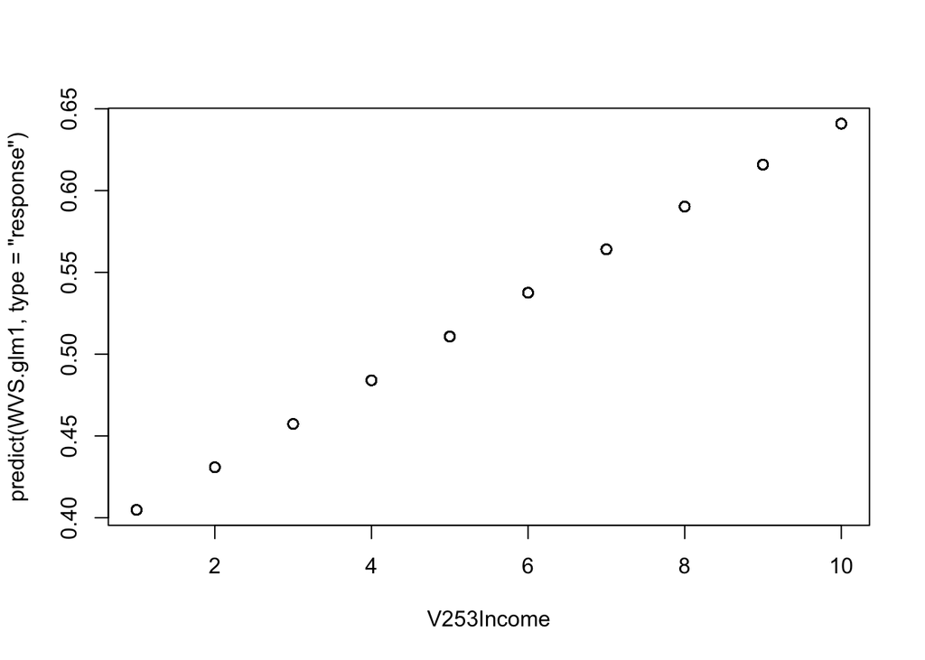

```r
WVS.glm1 = glm(V23MostTrusted ~ V253Income, family = binomial, data=WVS2)

plot(V253Income , predict(WVS.glm1,  type = "response") )
```

```r
summary(WVS.glm1)
```

```
##
## Call:
## glm(formula = V23MostTrusted ~ V253Income, family = binomial,
##     data = WVS2)
##
## Deviance Residuals:
##     Min       1Q   Median       3Q      Max
## -1.4312  -1.2420   0.9433   1.0701   1.3449
##
## Coefficients:
##             Estimate Std. Error z value Pr(>|z|)
## (Intercept) -0.49266    0.20098  -2.451 0.014236 *
## V253Income   0.10720    0.02791   3.841 0.000122 ***
## ---
## Signif. codes:  0 '***' 0.001 '**' 0.01 '*' 0.05 '.' 0.1 ' ' 1
##
## (Dispersion parameter for binomial family taken to be 1)
##
##     Null deviance: 954.93  on 694  degrees of freedom
## Residual deviance: 939.90  on 693  degrees of freedom
## AIC: 943.9
##
## Number of Fisher Scoring iterations: 4
```

7. Fit a glm with all the predictors in the previous stepwise model.

```r
Trust.full= glm(V23MostTrusted ~ V4FamilyImp    +V5FrndsImp+    V6LesrImp+  V7PoltcImp+ V8WorkImp+  V9RelgnImp+ factor(V11StateofHlth)+ V235Sex + V237Age + V238HighEducLev + V253Income+ factor(MaritalStatus), family=binomial)
Trust.null= glm(V23MostTrusted ~1,  family=binomial)
Trust.glm = step(Trust.null,  scope=list(Trust.null, upper=Trust.full), direction="forward")
```

```
## Start:  AIC=956.93
## V23MostTrusted ~ 1
##
##                          Df Deviance    AIC
## + V253Income              1   939.90 943.90
## + V238HighEducLev         1   945.17 949.17
## + V7PoltcImp              1   948.94 952.94
## + V237Age                 1   949.30 953.30
## + V8WorkImp               1   949.47 953.47
## + factor(MaritalStatus)   2   948.92 954.92
## + factor(V11StateofHlth)  3   948.18 956.18
## + V5FrndsImp              1   952.88 956.88
## <none>                        954.93 956.93
## + V6LesrImp               1   953.57 957.57
## + V9RelgnImp              1   954.40 958.40
## + V235Sex                 1   954.45 958.45
## + V4FamilyImp             1   954.88 958.88
##
## Step:  AIC=943.9
## V23MostTrusted ~ V253Income
##
##                          Df Deviance    AIC
## + V237Age                 1   926.43 932.43
## + V8WorkImp               1   933.96 939.96
## + V7PoltcImp              1   934.26 940.26
## + V238HighEducLev         1   936.20 942.20
## + factor(MaritalStatus)   2   934.99 942.99
## + V5FrndsImp              1   937.23 943.23
## <none>                        939.90 943.90
## + V235Sex                 1   938.91 944.91
## + V6LesrImp               1   939.11 945.11
## + V4FamilyImp             1   939.79 945.79
## + V9RelgnImp              1   939.80 945.80
## + factor(V11StateofHlth)  3   936.13 946.13
##
## Step:  AIC=932.43
## V23MostTrusted ~ V253Income + V237Age
##
##                          Df Deviance    AIC
## + V238HighEducLev         1   917.00 925.00
```

[output cut: 51 more lines]

```
## + V4FamilyImp             1   906.44 920.44
## + factor(MaritalStatus)   2   905.10 921.10
##
## Step:  AIC=918.2
## V23MostTrusted ~ V253Income + V237Age + V238HighEducLev + V7PoltcImp +
##     V8WorkImp + V5FrndsImp
##
##                          Df Deviance    AIC
## <none>                        904.20 918.20
## + factor(V11StateofHlth)  3   898.68 918.68
## + V9RelgnImp              1   903.29 919.29
## + V4FamilyImp             1   903.69 919.69
## + V235Sex                 1   903.74 919.74
## + V6LesrImp               1   903.88 919.88
## + factor(MaritalStatus)   2   902.73 920.73
```

```r
summary(Trust.glm)
```

```
##
## Call:
## glm(formula = V23MostTrusted ~ V253Income + V237Age + V238HighEducLev +
##     V7PoltcImp + V8WorkImp + V5FrndsImp, family = binomial)
##
## Deviance Residuals:
##     Min       1Q   Median       3Q      Max
## -2.2064  -1.1935   0.7731   1.0354   1.7190
##
## Coefficients:
##                  Estimate Std. Error z value Pr(>|z|)
## (Intercept)     -2.353626   0.689374  -3.414 0.000640 ***
## V253Income       0.122168   0.031437   3.886 0.000102 ***
## V237Age          0.023986   0.005922   4.050 5.11e-05 ***
## V238HighEducLev  0.154536   0.057794   2.674 0.007497 **
## V7PoltcImp      -0.257058   0.111206  -2.312 0.020803 *
## V8WorkImp        0.276453   0.115387   2.396 0.016581 *
## V5FrndsImp      -0.211134   0.136507  -1.547 0.121939
## ---
## Signif. codes:  0 '***' 0.001 '**' 0.01 '*' 0.05 '.' 0.1 ' ' 1
##
## (Dispersion parameter for binomial family taken to be 1)
##
##     Null deviance: 954.93  on 694  degrees of freedom
## Residual deviance: 904.20  on 688  degrees of freedom
## AIC: 918.2
##
## Number of Fisher Scoring iterations: 4
```

1. In the final step model, which variables are significant predictors of whether the person feels most people can be trusted? What do the positive or negative regression coefficients mean, in a practical sense (interpret the sign of the coefficients, not the numbers). Note you will need to look at the coding to know whether high numbers for a variable are better or worse.

2. Which is the most important single predictor of “V23MostTrusted”?

Comment: he most important single predictor of “V23MostTrusted” is V253Income.

3. Create a classification table for the final model. What proportion of individuals are correctly classified?

```r
predTrust = predict(Trust.glm, type = "response") > 0.5
table(V23MostTrusted, predTrust)
```

```
##               predTrust
## V23MostTrusted FALSE TRUE
##              0   125  184
##              1    89  297
```

===========================================

Some useful R code

```r
hist(residuals)
qqnorm(residuals)
qqline(residuals)
```

```r
FittedLinePlot = function(xydata, polyn = 1) {
    x = xydata[, 1]
    y = xydata[, 2]
    varname = names(xydata)
    model = lm(y ~ poly(x, polyn))
    pred.x = data.frame(x = min(x) + (0:100) * (max(x) - min(x))/100)
    pred.y = predict(model, newdata = pred.x, interval = "prediction")
    matplot(pred.x, pred.y, lty = c(1, 2, 2), col = c(1, 2, 2), type = "l", xlab = varname[1],
        ylab = varname[2])
    matpoints(x, y, pch = 1)
    datapred = predict(model, newdata = data.frame(x), interval = "prediction")
    cbind(xydata, datapred)
}

m.flp = FittedLinePlot(data.frame(Profits, MktValue), polyn=5)
```

```r
lm.null=   ?what should this be?
lm.full = lm(Satisfact2~ V4FamilyImp    +V5FrndsImp+    V6LesrImp+  V7PoltcImp+ V8WorkImp+  V9RelgnImp+ factor(V11StateofHlth)+ V235Sex + V237Age + V238HighEducLev + V253Income+ factor(MaritalStatus))

lms = step( lm.full, scope=list(lower=lm.null, upper=lm.full), direction="backward")
```

```r
n= length(Wtres)
(1:n)[Wtres==max(Wtres)]
Company[(1:n)[Wtres==max(Wtres)]]
```

```r
plot(x,   lm$fitted.values,    pch=group, col=group)
```

```r
PRESS <- function(linear.model) {
    #' calculate the predictive residuals
    pr <- residuals(linear.model)/(1 - lm.influence(linear.model)$hat)
    #' calculate the PRESS
    PRESS <- sum(pr^2)
    return(PRESS)
}

pred_r_squared <- function(linear.model) {
    #' Use anova() to get the sum of squares for the linear model
    lm.anova <- anova(linear.model)
    #' Calculate the total sum of squares
    tss <- sum(lm.anova$"Sum Sq")
    # Calculate the predictive R^2
    pred.r.squared <- 1 - PRESS(linear.model)/(tss)
    return(pred.r.squared)
}
```